# Loading Data

**Learning Objectives**

- Load external data with `read_csv` from a .csv file into a tibble.
- Describe what a tibble is.
- Summarize the contents of a tibble.
- Manipulate cartegorical data in R using factors

# Importing Data

[“From Modern Dive Section 5.1”](https://moderndive.com/5-tidy.html#tidy)

Almost everything you are typically going to do in R will require you to load data (at least at first), typically stored in a spreadsheet.

Spreadsheet data is often saved in one of the following formats:

- A *Comma Separated Values* `.csv` file. You can think of a `.csv` file as a bare-bones spreadsheet where:
  - Each line in the file corresponds to one row of data/one observation.
  - Values for each line are separated with commas. In other words, the values of different variables are separated by commas.
  - The first line is often, but not always, a header row indicating the names of the columns/variables.
- An Excel `.xlsx` file. This format is based on Microsoft’s proprietary Excel software. As opposed to a bare-bones `.csv` files, `.xlsx` Excel files sometimes contain a lot of meta-data, or put more simply, data about the data. Some examples of spreadsheet meta-data include the use of bold and italic fonts, colored cells, different column widths, and formula macros.
- A Google Sheets file, which is a “cloud” or online-based way to work with a spreadsheet. Google Sheets allows you to download your data in both comma separated values `.csv` and Excel `.xlsx` formats however: go to the Google Sheets menu bar -> File -> Download as -> Select “Microsoft Excel” or “Comma-separated values.”

Here we’ll cover two methods for importing `.csv` and `.xlsx` spreadsheet data: using the console and using RStudio’s graphical user interface (GUI).

### Using the console

First, let’s import a Comma Separated Values `.csv` file of data directly off the internet. The `.csv` file dem_score.csv accessible at https://moderndive.com/data/dem_score.csv contains ratings of the level of democracy in different countries spanning 1952 to 1992. Let’s use the `read_csv()` function from the `readr` package (loaded automatically with `library(tidyverse)`) to read it off the web, import it into R, and save it in a data frame called `dem_score`

```r
library(tidyverse)
dem_score_tbl <- read_csv("https://moderndive.com/data/dem_score.csv", col_type = cols())
dem_score_tbl
```

```
## # A tibble: 96 x 10
##    country   `1952` `1957` `1962` `1967` `1972` `1977` `1982` `1987` `1992`
##    <chr>      <dbl>  <dbl>  <dbl>  <dbl>  <dbl>  <dbl>  <dbl>  <dbl>  <dbl>
##  1 Albania       -9     -9     -9     -9     -9     -9     -9     -9      5
##  2 Argentina     -9     -1     -1     -9     -9     -9     -8      8      7
##  3 Armenia       -9     -7     -7     -7     -7     -7     -7     -7      7
##  4 Australia     10     10     10     10     10     10     10     10     10
##  5 Austria       10     10     10     10     10     10     10     10     10
##  6 Azerbaij…     -9     -7     -7     -7     -7     -7     -7     -7      1
##  7 Belarus       -9     -7     -7     -7     -7     -7     -7     -7      7
##  8 Belgium       10     10     10     10     10     10     10     10     10
##  9 Bhutan       -10    -10    -10    -10    -10    -10    -10    -10    -10
## 10 Bolivia       -4     -3     -3     -4     -7     -7      8      9      9
## # … with 86 more rows
```

Note that the `read_csv()` function is different than the `read.csv()` function. Among other things, `read_csv()` will store the data as a tibble and `read.csv()` (which is the built-in function in base R) will store the data as a data frame.

### Using the GUI interface

Let’s read in the exact same data saved in Excel format, but this time via RStudio’s graphical interface instead of via the R console. First download the Excel file `dem_score.xlsx` by clicking [“here”](https://moderndive.com/data/dem_score.xlsx), then 1. Go to the Files panel of RStudio.  
2. Navigate to the directory i.e. folder on your computer where the downloaded `dem_score.xlsx` Excel file is saved.  
3. Click on dem_score.xlsx.  
4. Click “Import Dataset…”

At this point you should see an image like this:

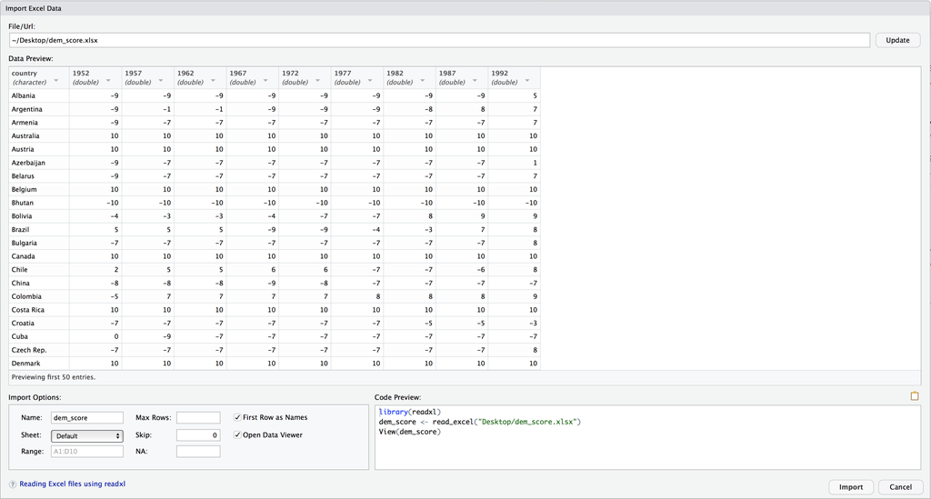

After clicking on the “Import” button on the bottom right RStudio, RStudio will save this spreadsheet’s data in a data frame called `dem_score` and display its contents in the spreadsheet viewer. Furthermore, note in the bottom right of the above image there exists a “Code Preview”: you can copy and paste this code to reload your data again later automatically instead of repeating the above manual point-and-click process.

Note that both methods have imported the data as a tibble. Just for fun we can compare this the same file loaded using `read.csv()`:

```r
dem_score_df <- read.csv("https://moderndive.com/data/dem_score.csv")
head(dem_score_df)
```

```
##      country X1952 X1957 X1962 X1967 X1972 X1977 X1982 X1987 X1992
## 1    Albania    -9    -9    -9    -9    -9    -9    -9    -9     5
## 2  Argentina    -9    -1    -1    -9    -9    -9    -8     8     7
## 3    Armenia    -9    -7    -7    -7    -7    -7    -7    -7     7
## 4  Australia    10    10    10    10    10    10    10    10    10
## 5    Austria    10    10    10    10    10    10    10    10    10
## 6 Azerbaijan    -9    -7    -7    -7    -7    -7    -7    -7     1
```

Notice that I’ve used `head`, which gives me only the first 6 rows of the data sheet. What happens if you type `dem_score_df` into the console? Note that this is different than when we read in `dem_score` as a tibble.